# R Notebook

```r
library(tidyverse)
library(CodeClanData)
```

Question 1.

Load in the libraries you need, and look at the backpack data. Take note of variable names and dimensions.

```r
backpack <- CodeClanData::backpack
summary(backpack)
```

```
##  backpack_weight  body_weight        ratio         back_problems      major
##  Min.   : 2.00   Min.   :105.0   Min.   :0.01600   Min.   :0.00   Bio    : 9
##  1st Qu.: 8.00   1st Qu.:130.0   1st Qu.:0.05121   1st Qu.:0.00   Bus    : 8
##  Median :11.00   Median :147.5   Median :0.07143   Median :0.00   LS     : 7
##  Mean   :11.66   Mean   :153.1   Mean   :0.07713   Mean   :0.32   ME     : 6
##  3rd Qu.:14.25   3rd Qu.:170.0   3rd Qu.:0.09630   3rd Qu.:1.00   CPE    : 5
##  Max.   :35.00   Max.   :270.0   Max.   :0.18103   Max.   :1.00   AGB    : 4
##                                                                   (Other):61
##       year         sex     status     units
##  Min.   :0.0   Female:55   G: 3   Min.   : 0.00
##  1st Qu.:2.0   Male  :45   U:97   1st Qu.:13.00
##  Median :3.0                      Median :15.00
##  Mean   :3.2                      Mean   :14.27
##  3rd Qu.:4.0                      3rd Qu.:16.00
##  Max.   :6.0                      Max.   :19.00
##
```

```r
view(backpack)
```

Question 2.

What is the distribution of backpack weights that students are carrying? Choose an appropriate graph to show the distribution.

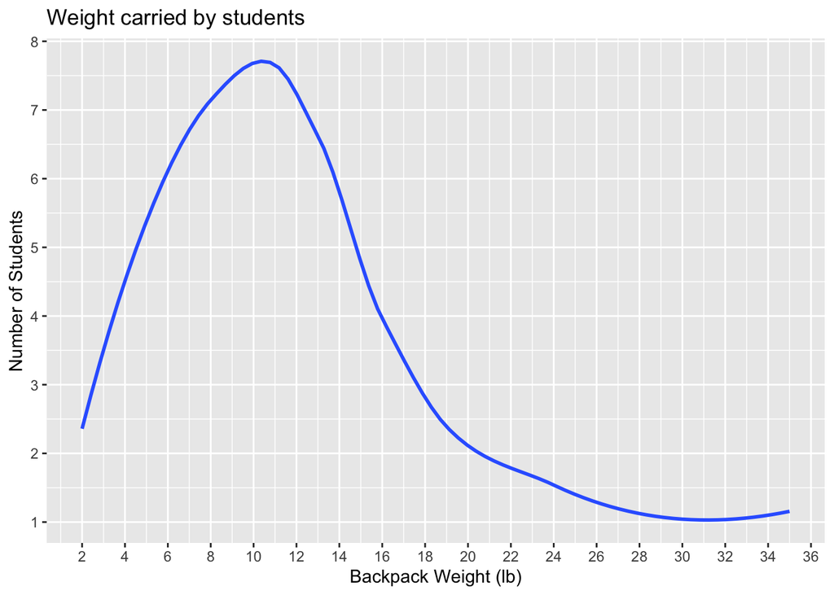

```r
backpack %>%
 group_by(backpack_weight) %>%
 summarise(counts = n()) %>%
ggplot() +
  geom_smooth(aes(x = backpack_weight, y = counts), se = FALSE) +
  labs(
  x = "Backpack Weight (lb)",
   y = "Number of Students",
   title = "Weight carried by students"
 ) +
  scale_x_continuous(
    breaks = seq(2,40, by = 2)) +
  scale_y_continuous(
    breaks = seq(1,12, by = 1))
```

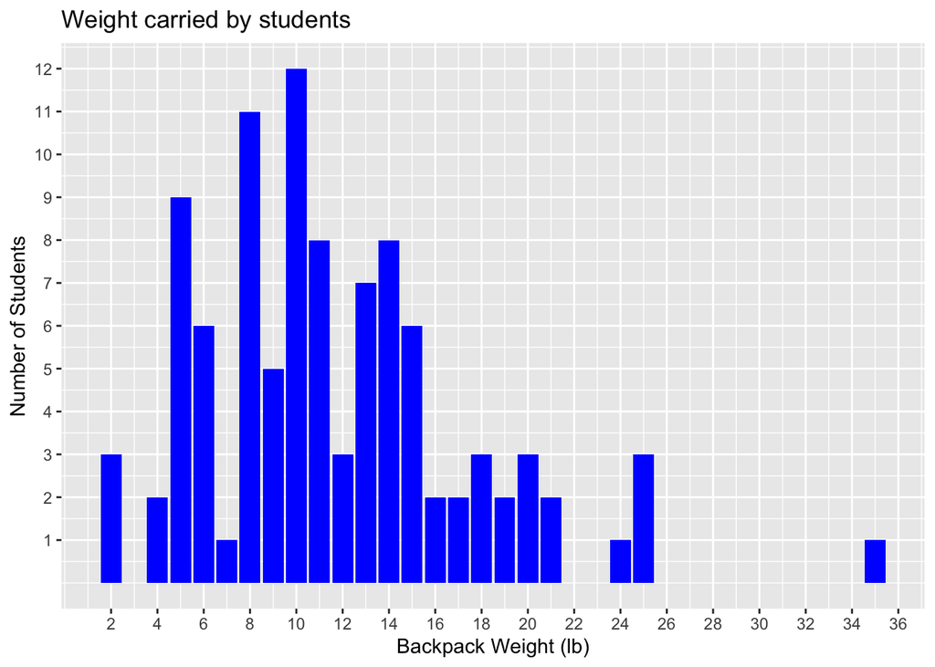

```r
backpack %>%
 group_by(backpack_weight) %>%
 summarise(counts = n()) %>%
ggplot() +
  geom_col(aes(x = backpack_weight, y = counts), fill = "blue") +
  labs(
  x = "Backpack Weight (lb)",
   y = "Number of Students",
   title = "Weight carried by students") +
  scale_x_continuous(
    breaks = seq(2,40, by = 2)) +
 scale_y_continuous(
    breaks = seq(1,12, by = 1))
```

Question 3.

Are there differences in backpack weight between sex?

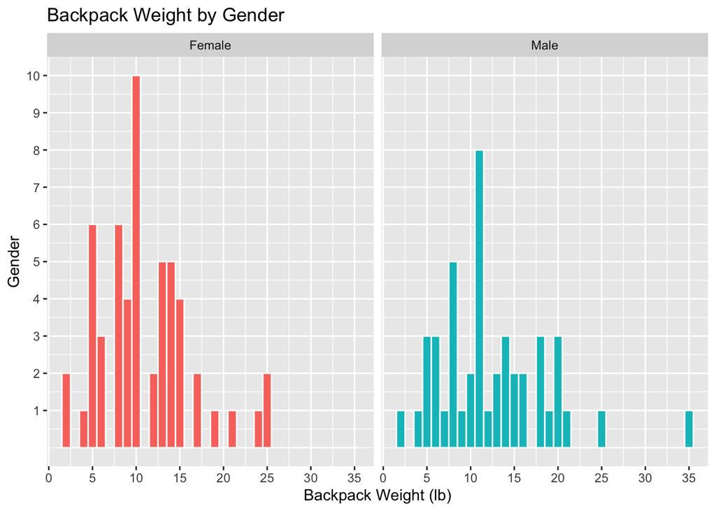

```r
ggplot(backpack) +
  geom_histogram(aes(x = backpack_weight, fill = sex), col = "white",   show.legend = FALSE, binwidth = 1) +
  facet_wrap(~ sex) +
    labs(
    x = "Backpack Weight (lb)",
    y = "Gender",
    title = "Backpack Weight by Gender"
    ) +
  scale_x_continuous(
    breaks = seq(0,40, by = 5)) +
 scale_y_continuous(
    breaks = seq(1,10, by = 1))
```

Question 4.

What is the relationship between body weight and backpack weight?

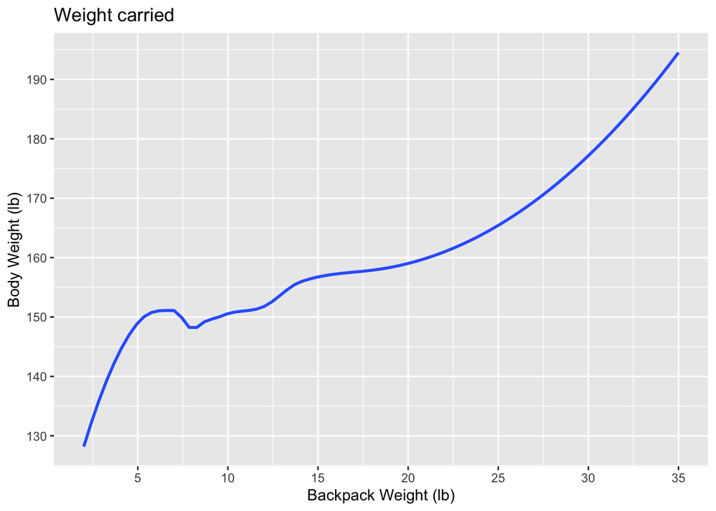

```r
ggplot(backpack) +
  geom_smooth(aes(x = backpack_weight, y = body_weight), se = FALSE) +
   labs(
    x = "Backpack Weight (lb)",
    y = "Body Weight (lb)",
    title = "Weight carried"
    ) +
    scale_x_continuous(
    breaks = seq(0, 40, by = 5)) +
 scale_y_continuous(
    breaks = seq(100, 200, by = 10))
```

As an individual weight increases they carry a heavier bag, this seems to make sense as larger individuals would expect to be capable of carrying a heavier backpack

Question 5.

Is this relationship different between men and women? Choose an appropriate plot and interpret your findings.

Question 6.

What proportion of students report back pain?

Question 7.

Is this proportion different between men and women?

Question 8.

Now you’ve investigated your data separately, create plots to describe the relationship between backpack weight, body weight, gender and reported backpain.

Try both backpack_weight and body_weight as well as the ratio.

Hint: faceting would be useful here.

```r
backpack
```

| backpack_weight | body_weight | ratio | back_problems | major | year | sex | status | units |
| --- | --- | --- | --- | --- | --- | --- | --- | --- |
| 9 | 125 | 0.0720000 | 1 | Bio | 3 | Female | U | 13 |
| 8 | 195 | 0.0410256 | 0 | Philosophy | 5 | Male | U | 12 |
| 10 | 120 | 0.0833333 | 1 | GRC | 4 | Female | U | 14 |
| 6 | 155 | 0.0387097 | 0 | CSC | 6 | Male | G | 0 |
| 8 | 180 | 0.0444444 | 0 | EE | 2 | Female | U | 14 |
| 5 | 240 | 0.0208333 | 0 | History | 0 | Male | G | 0 |
| 8 | 170 | 0.0470588 | 0 | CM | 3 | Male | U | 15 |
| 4 | 185 | 0.0216216 | 1 | ARCE | 5 | Female | U | 18 |
| 5 | 130 | 0.0384615 | 0 | Bio | 4 | Female | U | 14 |
| 2 | 120 | 0.0166667 | 0 | Bio | 5 | Female | U | 8 |

[output cut: 90 more lines]